# StatData2 - Forelæsning d. 3/10-2017

[figure not shown]

[figure not shown]

[figure not shown]

[figure not shown]

[figure not shown]

[figure not shown]

[figure not shown]

[figure not shown]

# Undersøg forsøgsdesign

### Kommentarer

Indlæs data og lav tabeller til undersøgelse af forsøgsdesign:

- Vi ser at forsøget er et balanceret 3-faktorforsøg med to gentagelser for hver kombination af de tre faktorer *feed*, *packaging* og *storage*.
- Vi ser, at faktoren *animal* er finere end *feed*, og at hver kombination af *packaging* og *storage* optræder præcis een gang for hvert niveau af *animal*

Konklusion:

Forsøget er et split-plot forsøg med:

- *animal* som helplot
- *feed* som helplot-faktor
- *storaging x packaging* som delplot-faktor

### Indlæs data

```r
ex83<-read.table("../data/ex83.txt",header=T)
head(ex83)
```

```
  animal feed packaging storage ran
1      1    1         1       1 2.0
2      1    1         1       2 2.3
3      1    1         1       3 2.3
4      1    1         2       1 0.6
5      1    1         2       2 2.1
6      1    1         2       3 2.1
```

```r
ex83$feedfac<-factor(ex83$feed)
ex83$animalfac<-factor(ex83$animal)
ex83$storefac<-factor(ex83$storage)
ex83$packfac<-factor(ex83$packaging)
```

### Tabel: feed x pack x storage

```r
with(ex83, table(feed, packaging, storage))
```

```
, , storage = 1

    packaging
feed 1 2
   1 2 2
   2 2 2

, , storage = 2

    packaging
feed 1 2
   1 2 2
   2 2 2

, , storage = 3

    packaging
feed 1 2
   1 2 2
   2 2 2
```

### Tabel: animal x feed

```r
with(ex83, table(animal, feed))
```

```
      feed
animal 1 2
     1 6 0
     2 0 6
     3 6 0
     4 0 6
```

### Tabel: animal x pack x storage

```r
with(ex83, table(packaging, storage, animal))
```

```
, , animal = 1

         storage
packaging 1 2 3
        1 1 1 1
        2 1 1 1

, , animal = 2

         storage
packaging 1 2 3
        1 1 1 1
        2 1 1 1

, , animal = 3

         storage
packaging 1 2 3
        1 1 1 1
        2 1 1 1

, , animal = 4

         storage
packaging 1 2 3
        1 1 1 1
        2 1 1 1
```

# Modelreduktion

### Kommentarer

Husk at modellerne skal estimeres med *method = ‘ML’*, hvis vi ønsker at lave likelihood ratio test.

Hvis du benytter *lmer()*-funktionen benyttes i stedet *REML = F*.

Vi konkluderer, at

### Test for vekselvirkninger

```r
library(nlme)
m0<-lme(ran~feedfac*storefac*packfac,random=~1|animalfac,data=ex83,method='ML')
m1<-lme(ran~feedfac*storefac+feedfac*packfac+storefac*packfac,random=~1|animalfac,data=ex83,method='ML')
anova(m1,m0)
```

```
   Model df      AIC      BIC   logLik   Test  L.Ratio p-value
m1     1 12 20.85119 34.98783 1.574406
m0     2 14 23.70594 40.19870 2.147029 1 vs 2 1.145247   0.564
```

```r
m2<-lme(ran~feedfac*storefac+feedfac*packfac,random=~1|animalfac,data=ex83,method='ML')
anova(m2,m1)
```

```
   Model df      AIC      BIC    logLik   Test  L.Ratio p-value
m2     1 10 18.10106 29.88160 0.9494699
m1     2 12 20.85119 34.98783 1.5744057 1 vs 2 1.249872  0.5353
```

```r
m3<-lme(ran~feedfac*storefac+packfac,random=~1|animalfac,data=ex83,method='ML')
anova(m3,m2)
```

```
   Model df      AIC      BIC    logLik   Test  L.Ratio p-value
m3     1  9 17.88619 28.48867 0.0569055
m2     2 10 18.10106 29.88160 0.9494699 1 vs 2 1.785129  0.1815
```

```r
m4<-lme(ran~feedfac+storefac+packfac,random=~1|animalfac,data=ex83,method='ML')
anova(m4,m3)
```

```
   Model df      AIC      BIC     logLik   Test  L.Ratio p-value
m4     1  7 15.47595 23.72232 -0.7379734
m3     2  9 17.88619 28.48867  0.0569055 1 vs 2 1.589758  0.4516
```

### Test for hovedeffekter

```r
m5a<-lme(ran~feedfac+storefac,random=~1|animalfac,data=ex83,method='ML')
anova(m5a,m4)
```

```
    Model df      AIC      BIC    logLik   Test  L.Ratio p-value
m5a     1  6 28.23026 35.29858 -8.115131
m4      2  7 15.47595 23.72232 -0.737973 1 vs 2 14.75432   1e-04
```

```r
m5b<-lme(ran~feedfac+packfac,random=~1|animalfac,data=ex83,method='ML')
anova(m5b,m4)
```

```
    Model df      AIC      BIC     logLik   Test  L.Ratio p-value
m5b     1  5 42.33339 48.22366 -16.166697
m4      2  7 15.47595 23.72232  -0.737973 1 vs 2 30.85745  <.0001
```

```r
m5c<-lme(ran~packfac+storefac,random=~1|animalfac,data=ex83,method='ML')
anova(m5c,m4)
```

```
    Model df      AIC      BIC    logLik   Test  L.Ratio p-value
m5c     1  6 24.61213 31.68045 -6.306063
m4      2  7 15.47595 23.72232 -0.737973 1 vs 2 11.13618   8e-04
```

### F-test for effekt af feed

Alle relevante MSe-størrelser (-Mean Sq.) kan aflæses af følgende. Alternativt skal de konstrueres “i hånden” som beskrevet på forelæsningsslides fra undervisningsuge 4

```r
mod4 <- lm(ran ~ packfac + storefac + feedfac + animalfac, data = ex83)
anova(mod4)
```

```
Analysis of Variance Table

Response: ran
          Df Sum Sq Mean Sq F value    Pr(>F)
packfac    1 1.2604  1.2604 18.0249 0.0005453 ***
storefac   2 3.9025  1.9512 27.9043 4.268e-06 ***
feedfac    1 4.7704  4.7704 68.2205 2.357e-07 ***
animalfac  2 0.3142  0.1571  2.2464 0.1362457
Residuals 17 1.1888  0.0699
---
Signif. codes:  0 '***' 0.001 '**' 0.01 '*' 0.05 '.' 0.1 ' ' 1
```

```r
Ftest <- 4.7704/0.1571
Ftest
```

```
[1] 30.36537
```

```r
1 - pf(Ftest,1,2)
```

```
[1] 0.03138988
```

### Simulering af p-værdi for test af feed

Vi husker fra outputted ovenfor, at den observerede værdi af likelihood ratio teststørrelsen er givet ved L.Ratio = 11.13618.

```r
sim <- simulate.lme(m5c, m2 = m4, nsim = 1000, seed = 2016)
lr.sim<-2*(sim$alt$ML-sim$null$ML)
psim<-sum(lr.sim > 11.11618)/1000
psim
```

```
[1] 0.034
```

# Estimater

### Standardparametrisering

Husk at genfitte modellen med *method = ‘REML’* for at få mere pålidelige variansestimater.

```r
mfinal<-lme(ran~feedfac+storefac+packfac,random=~1|animalfac,data=ex83,method='REML')
summary(mfinal)
```

```
Linear mixed-effects model fit by REML
 Data: ex83
       AIC      BIC    logLik
  28.81426 35.42534 -7.407132

Random effects:
 Formula: ~1 | animalfac
        (Intercept)  Residual
StdDev:   0.1205245 0.2644361

Fixed effects: ran ~ feedfac + storefac + packfac
                 Value Std.Error DF   t-value p-value
(Intercept)  1.4750000 0.1477535 17  9.982845  0.0000
feedfac2    -0.8916667 0.1618041  2 -5.510780  0.0314
storefac2    0.7625000 0.1322181 17  5.766988  0.0000
storefac3    0.9250000 0.1322181 17  6.996018  0.0000
packfac2    -0.4583333 0.1079556 17 -4.245573  0.0005
 Correlation:
          (Intr) fedfc2 strfc2 strfc3
feedfac2  -0.548
storefac2 -0.447  0.000
storefac3 -0.447  0.000  0.500
packfac2  -0.365  0.000  0.000  0.000

Standardized Within-Group Residuals:
       Min         Q1        Med         Q3        Max
-1.7680164 -0.5805387 -0.1070425  0.5947398  1.7930198

Number of Observations: 24
Number of Groups: 4
```

```r
VarCorr(mfinal) ### giver kun variansestimater
```

```
animalfac = pdLogChol(1)
            Variance   StdDev
(Intercept) 0.01452614 0.1205245
Residual    0.06992647 0.2644361
```

### Relevel (*storage = 2* som reference)

Hvis man istedet ønsker at bruge *storefac = 2* som reference, så kan man bruge *relevel*-funktionen som vist nedenfor.

```r
mfinal2<-lme(ran~feedfac+relevel(storefac, ref = "2")+packfac,random=~1|animalfac,data=ex83,method='REML')
summary(mfinal2)
```

```
Linear mixed-effects model fit by REML
 Data: ex83
       AIC      BIC    logLik
  28.81426 35.42534 -7.407132

Random effects:
 Formula: ~1 | animalfac
        (Intercept)  Residual
StdDev:   0.1205245 0.2644361

Fixed effects: ran ~ feedfac + relevel(storefac, ref = "2") + packfac
                                   Value Std.Error DF   t-value p-value
(Intercept)                    2.2375000 0.1477535 17 15.143469  0.0000
feedfac2                      -0.8916667 0.1618041  2 -5.510780  0.0314
relevel(storefac, ref = "2")1 -0.7625000 0.1322181 17 -5.766988  0.0000
relevel(storefac, ref = "2")3  0.1625000 0.1322181 17  1.229030  0.2358
packfac2                      -0.4583333 0.1079556 17 -4.245573  0.0005
 Correlation:
                              (Intr) fedfc2 r(,r="2")1 r(,r="2")3
feedfac2                      -0.548
relevel(storefac, ref = "2")1 -0.447  0.000
relevel(storefac, ref = "2")3 -0.447  0.000  0.500
packfac2                      -0.365  0.000  0.000      0.000

Standardized Within-Group Residuals:
       Min         Q1        Med         Q3        Max
-1.7680164 -0.5805387 -0.1070425  0.5947398  1.7930198

Number of Observations: 24
Number of Groups: 4
```

Heraf kan vi f.x. aflæse, at harskheden svarende til *storefac = 3* ligger 0.1625 over reference niveauet for *storefac = 2* og at denne forskel ikke er statistisk signifikant (p=0.2358).

# Modelkontrol

### Kommentarer

Neden for vises nogle vigtige elementer i at kontrollere modellens forudsætninger.

R-kode

```r
modKontrol<-lm(ran~feedfac*storefac*packfac+animalfac,data=ex83)
plot(predict(modKontrol),rstandard(modKontrol))
qqnorm(rstandard(modKontrol))
abline(0,1)
```

Figurerne giver ikke anledning til at betvivle antagelserne om varianshomogenitet og normalfordelte fejl.

### Residualplot

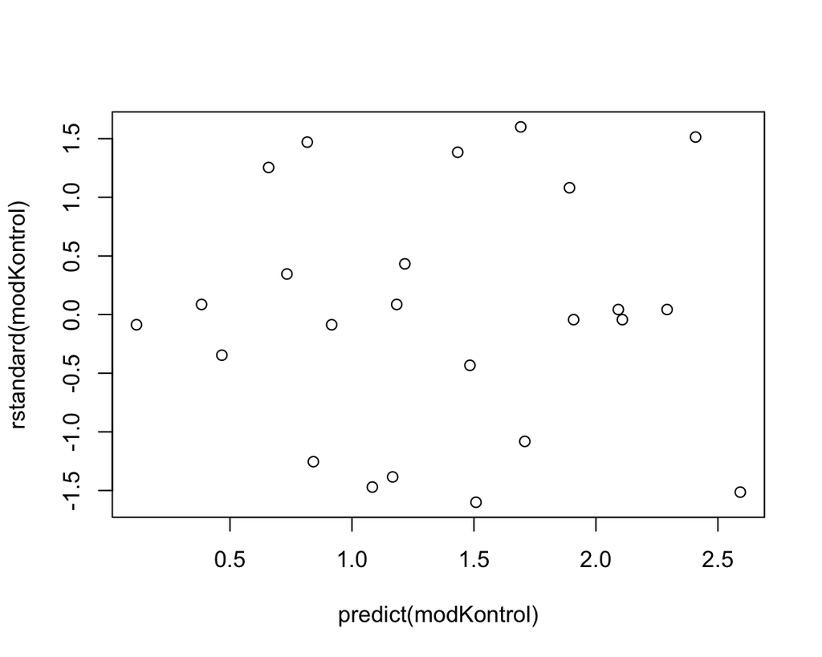

### QQ-plot

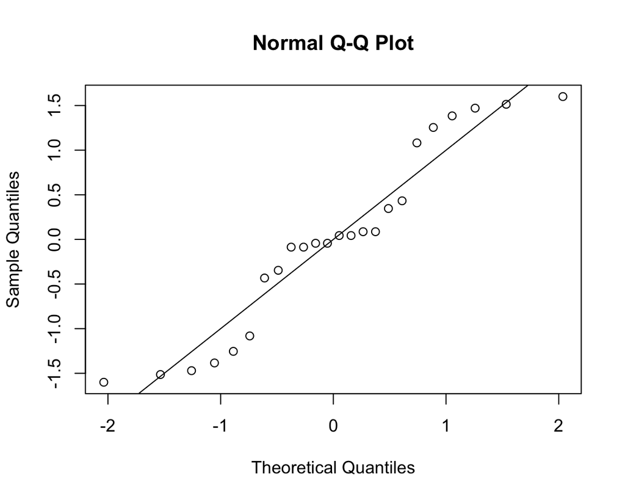

# Test for tilfældig effekt (animalfac)

Her beskrives, hvordan man kan teste, om den tilfældige faktor *animal* bidrager væsentlig til variationen i data. Man kan tvinge R til at lave det relevante F-test for hypotesen $H_0: \sigma_{animal}^2=0$.

```r
model0<-lm(ran~feedfac*storefac*packfac+animalfac,data=ex83)
model1<-lm(ran~feedfac*storefac*packfac,data=ex83)
anova(model1,model0)
```

```
Analysis of Variance Table

Model 1: ran ~ feedfac * storefac * packfac
Model 2: ran ~ feedfac * storefac * packfac + animalfac
  Res.Df     RSS Df Sum of Sq      F Pr(>F)
1     12 1.20500
2     10 0.89083  2   0.31417 1.7633 0.2208
```

P-værdien bliver p=0.22. Man kunne således argumentere for, at *animal* kan udelades. Man vil dog oftest ikke være interesseret i at fjerne en enkelt tilfældig effekt af modellen.

# Manipulationer med data

### Om forsøgets formål

Vores målinger er naturligt inddelt i grupper efter hvilket dyr/individ de stammer fra.

Vi er som sådan ikke interesseret i at drage konklusioner, som kun specifikt for de 28 dyr i forsøget, så det vil være naturligt at inddrage *goat* som en tilfældig faktor i modellen.

Det *nye* er, at de 5 målinger på hvert dyr er naturligt ordnet efter til hvilket tidspunkt de er taget. Dette kan være nyttig information, hvis man ønsker at forstå og beskrive afhængighedsstrukturen imellem de målinger, som er taget på samme individ.

### Indlæsning af data

```r
goatdata <- read.table("../data/goats1.txt", header=T)
head(goatdata)
```

```
  goat feed   w0 day weight
1    1    1 20.4   0   20.4
2    1    1 20.4  26   21.0
3    1    1 20.4  45   21.5
4    1    1 20.4  61   21.3
5    1    1 20.4  91   22.3
6    2    1 10.3   0   10.3
```

```r
goatdata$feedfac<-factor(goatdata$feed)
goatdata$goatfac<-factor(goatdata$goat)
goatdata$dayfac<-factor(goatdata$day)
```

### Tabeller

```r
table(goatdata$goat, goatdata$day)
```

```
     0 26 45 61 91
  1  1  1  1  1  1
  2  1  1  1  1  1
  3  1  1  1  1  1
  4  1  1  1  1  1
  5  1  1  1  1  1
  6  1  1  1  1  1
  7  1  1  1  1  1
  8  1  1  1  1  1
  9  1  1  1  1  1
  10 1  1  1  1  1
  11 1  1  1  1  1
  12 1  1  1  1  1
  13 1  1  1  1  1
  14 1  1  1  1  1
  15 1  1  1  1  1
  16 1  1  1  1  1
  17 1  1  1  1  1
  18 1  1  1  1  1
  19 1  1  1  1  1
  20 1  1  1  1  1
  21 1  1  1  1  1
  22 1  1  1  1  1
  23 1  1  1  1  1
  24 1  1  1  1  1
  25 1  1  1  1  1
  26 1  1  1  1  1
  27 1  1  1  1  1
  28 1  1  1  1  1
```

### Tabeller med tidyverse

R pakken *tidyverse* indeholder mange værktøjer, som gør det lettere at arbejde med data i R. Prøv at køre nogle af følgende kommandoer i R (husk at installere R pakken først på din computer).

```r
library(tidyverse)
count(goatdata, goat, day)
```

```
# A tibble: 140 x 3
    goat   day     n
   <int> <int> <int>
 1     1     0     1
 2     1    26     1
 3     1    45     1
 4     1    61     1
 5     1    91     1
 6     2     0     1
 7     2    26     1
 8     2    45     1
 9     2    61     1
10     2    91     1
# ... with 130 more rows
```

# Visualisering af data

### Optegning af figurer for data

Man interesserer sig overordnet set for to ting

- den gennemsnitlige vækst for gruppen af individer, der har modtaget samme foderbehandling (average profiles)
- de individuelle vækstkurver som funktion af tiden for enkelte dyr (subject profiles)

Særligt den sidste figur (subject profiles) har stor indflydelse på, hvilken statistisk model man vil bruge til at modellere variationen i data. En anden vigtigt pointe her er, at gennemsnitkurverne (average profiles) godt kan se ens ud for to forskellige datasæt, hvor *subject profiles* er ret forskellige.

Vi viser forskellige former for grafik

- funktionen *interaction.plot()* kan bruges til at lave average og subject profiles, men det er ikke lette at få til at se pæne ud
- standard grafik i R kan med lidt øvelses bruges til at lave pæne figurer i R
- R pakken *ggplot2* benyttes idag af de fleste (?)

### interaction.plot (kode)

```r
par(mfrow=c(2,2))
interaction.plot(goatdata$dayfac,goatdata$goat,goatdata$weight
                 , xlab = "day", ylab = "weight"
                 , trace.label = "goat")
interaction.plot(goatdata$dayfac,goatdata$goat,goatdata$weight-goatdata$w0
                 , xlab = "day", ylab = "weight increase"
                 , trace.label = "goat")
interaction.plot(goatdata$dayfac,goatdata$feed,goatdata$weight
                 , xlab = "day", ylab = "weight"
                 , trace.label = "goat")
interaction.plot(goatdata$dayfac,goatdata$feed,goatdata$weight-goatdata$w0
                 , xlab = "day", ylab = "weight increase", trace.label = "goat")

par(mfrow=c(1,1))
```

### interaction.plot (figur)

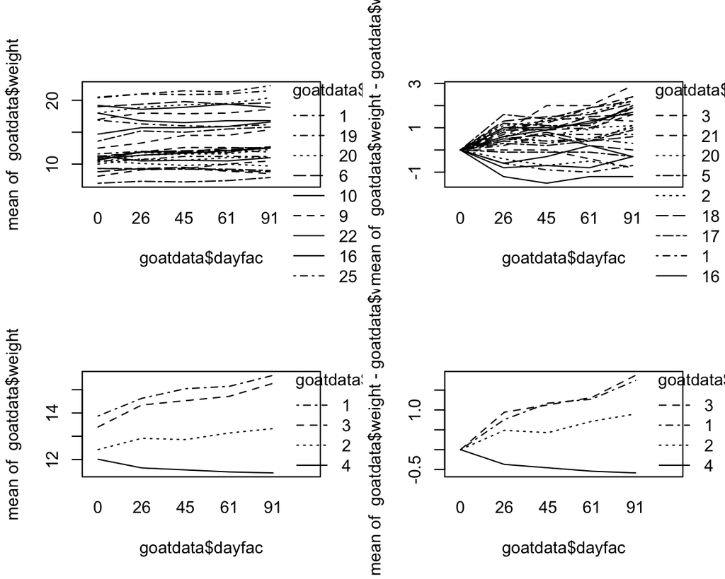

### Figurer med korrekt tidsakse (standard grafik i R)

Et væsentligt problem med figurerne i foregående afsnit er, at tidsaksen er forkert. Dette kan fixed ved at man manuelt plotter de *rigtige* værdier af variablen *day* på x-aksen.

Man kan en for en tegne kurverne for de 28 geder …

```r
plot(goatdata$day[1:5],goatdata$weight[1:5],type='l',ylim=c(0,25))
lines(goatdata$day[6:10],goatdata$weight[6:10])
lines(goatdata$day[11:15],goatdata$weight[11:15])
```

eller man kan lave en smart løsning med at skrive en løkke …

```r
plot(goatdata$day[1:5],goatdata$weight[1:5],type='l',ylim=c(0,25)
     , xlab = "Day", ylab = "Weight (kg)")
for(i in 1:28){
lines(goatdata$day[(i-1)*5+1:5],goatdata$weight[(i-1)*5+1:5])
}
```

### Standardgrafik (figur)

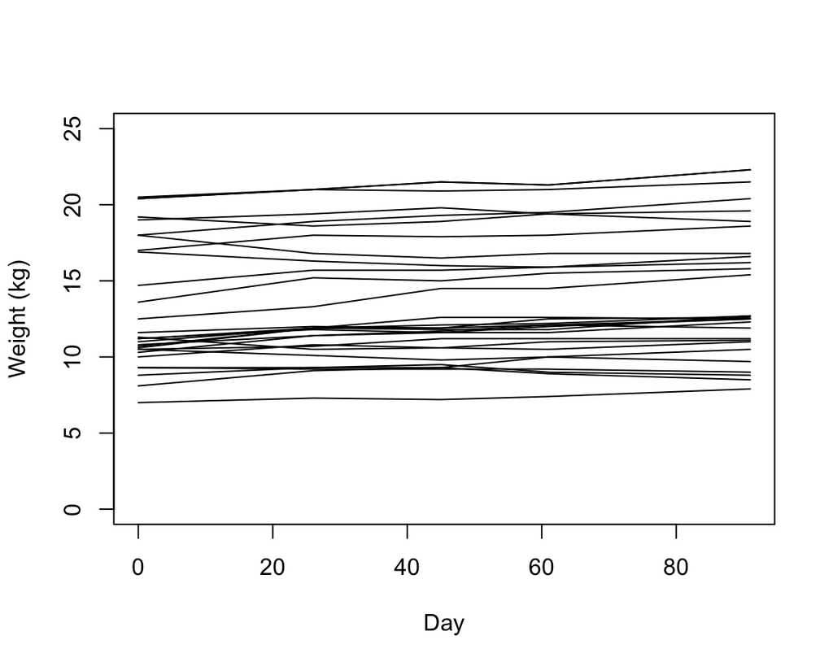

### Average profiles med tapply-funktionen

Brug *tapply*-funktionen til at udregne gennemsnit for alle kombinationer af *feed* og *day*.

Eksperimenter med at køre følgende kode

```r
meanTable<-with(goatdata,tapply(weight,list(day,feed),mean))
meanTable
matplot(meanTable,type='b', pch="o",ylab="Weight",xlab="Time (days)")
### Hvis man ønsker korrekte labels på x-akse
matplot(meanTable,type='b', pch="o",ylab="Weight (kg)",xlab="Time (days)",axes=FALSE)
axis(side=2,at=10:16)
axis(side=1,at=1:5,labels=c(0,26,45,61,91))
title("Weight increase of goats")
legend(1,15.8,col=1:4,lty=1:4,legend=c("feed 1","feed 2","feed 3","feed 4")
,bty='n')

### Hvis man ønsker korrekte labels på x-akse og korrekt placering
matplot(c(0,26,45,61,91),meanTable,type='b', pch="o",ylab="Weight (kg)"
,xlab="Time (days)")
title("Weight increase of goats")
legend(0,15.8,col=1:4,lty=1:4,legend=c("feed 1","feed 2","feed 3","feed 4")
,bty='n')
```

### Average profile (figur)

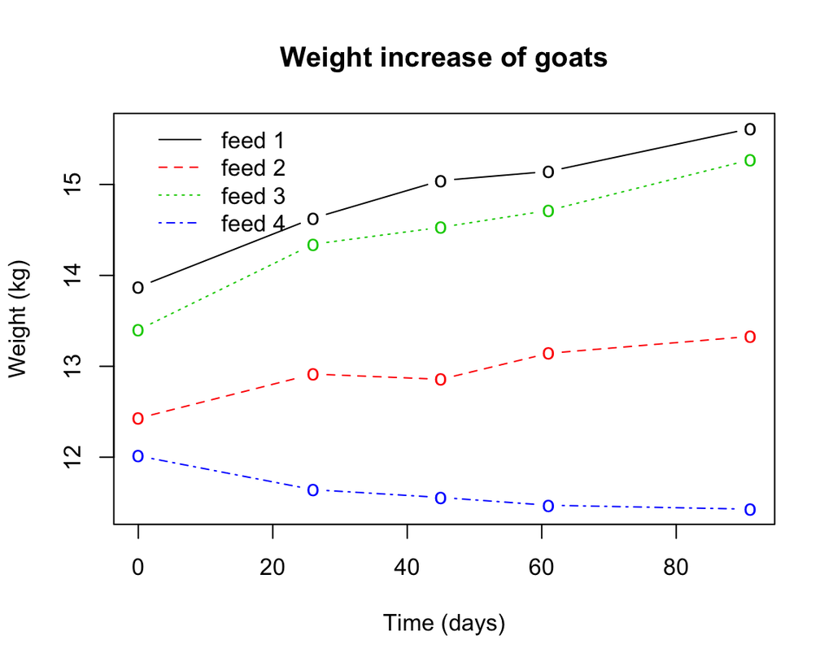

### ggplot (kode)

Tre forskellige figurer

```r
ggplot(data = goatdata) + geom_line(aes(x = day, y = weight, group = goat), color = "blue") + labs(x = "Weight (kg)", y = "Days")
```

```r
ggplot(data = goatdata) + geom_line(aes(x = day, y = weight - w0, group = goat), color = "blue") + labs(x = "Weight increase (kg)", y = "Days")
```

```r
ggplot(data = goatdata) + geom_line(aes(x = day, y = weight - w0, group = goat, color = feedfac)) + labs(x = "Weight increase (kg)", y = "Days")
```

### ggplot (figur 1)

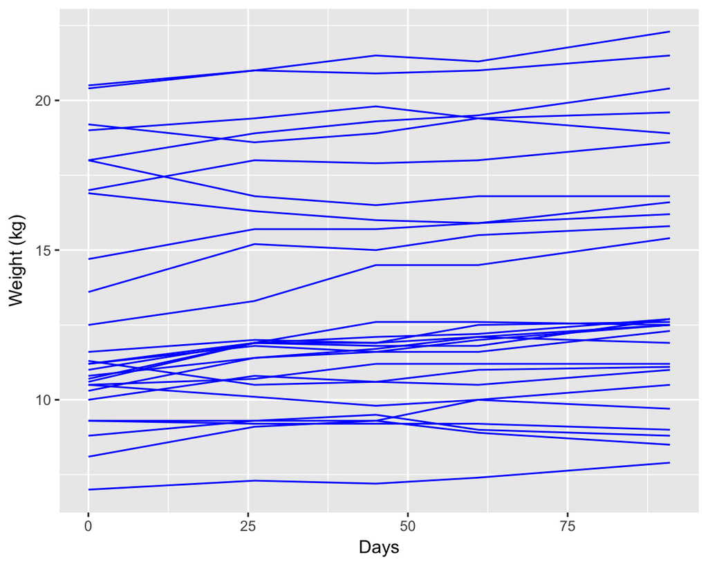

### ggplot (figur 2)

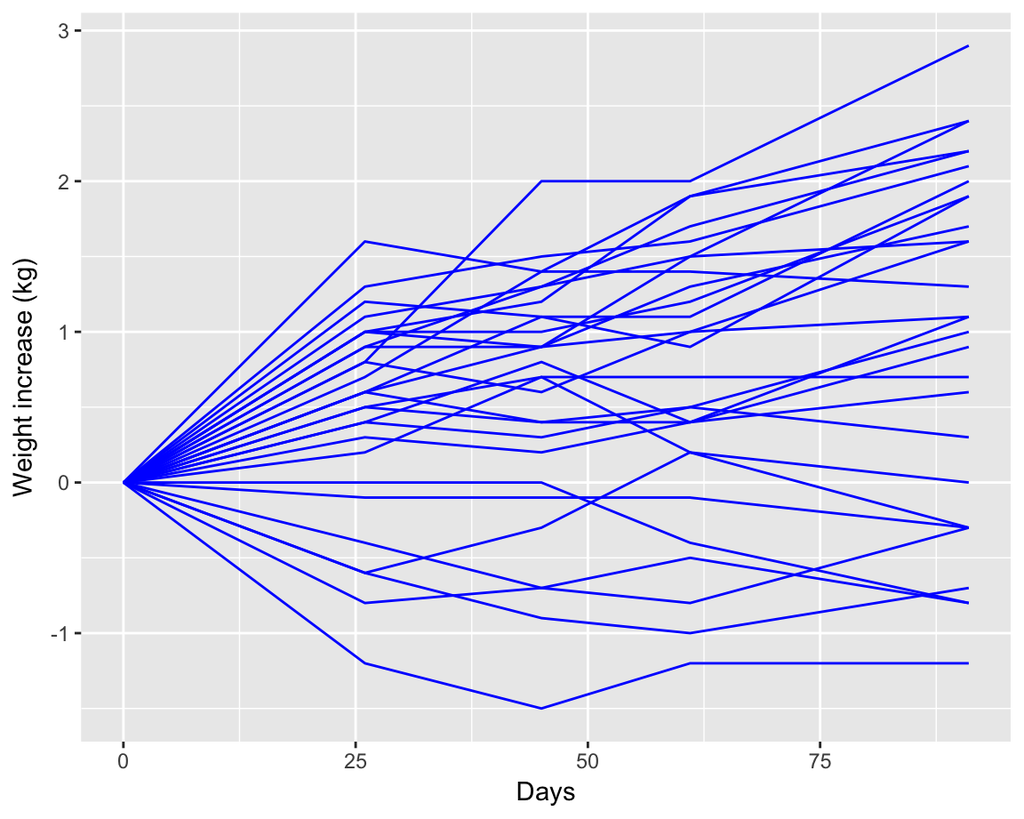

### ggplot (figur 3)

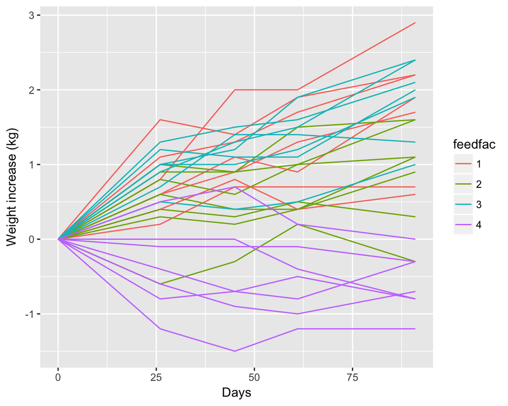

# Analyse af tilvækst fra day 0 til day 91

### Lav ny variabel

Lav datasæt hvor vi kun betragter tilvæksten fra day 0 til day 91 for hver ged. Datasættet indeholder kun 28 værdier svarende til en målinger per ged.

```r
head(goatdata, 10 )
```

```
   goat feed   w0 day weight feedfac goatfac dayfac
1     1    1 20.4   0   20.4       1       1      0
2     1    1 20.4  26   21.0       1       1     26
3     1    1 20.4  45   21.5       1       1     45
4     1    1 20.4  61   21.3       1       1     61
5     1    1 20.4  91   22.3       1       1     91
6     2    1 10.3   0   10.3       1       2      0
7     2    1 10.3  26   11.4       1       2     26
8     2    1 10.3  45   11.6       1       2     45
9     2    1 10.3  61   12.0       1       2     61
10    2    1 10.3  91   12.5       1       2     91
```

```r
goatdata91 <- subset(goatdata, day == 91)
head(goatdata91)
```

```
   goat feed   w0 day weight feedfac goatfac dayfac
5     1    1 20.4  91   22.3       1       1     91
10    2    1 10.3  91   12.5       1       2     91
15    3    1 12.5  91   15.4       1       3     91
20    4    1 10.8  91   12.5       1       4     91
25    5    1 13.6  91   15.8       1       5     91
30    6    1 19.0  91   19.6       1       6     91
```

```r
dim(goatdata91)
```

```
[1] 28  8
```

```r
goatdata91$incr <- goatdata91$weight - goatdata91$w0
head(goatdata91)
```

```
   goat feed   w0 day weight feedfac goatfac dayfac incr
5     1    1 20.4  91   22.3       1       1     91  1.9
10    2    1 10.3  91   12.5       1       2     91  2.2
15    3    1 12.5  91   15.4       1       3     91  2.9
20    4    1 10.8  91   12.5       1       4     91  1.7
25    5    1 13.6  91   15.8       1       5     91  2.2
30    6    1 19.0  91   19.6       1       6     91  0.6
```

### 1-sidet ANOVA (simpel løsning)

Ved brug af en 1-sidet ANOVA kan vi test om der er signfikante forskelle i tilvæksten fra day 0 til day 91 for dyr i de 4 forskellige grupper givet ved faktoren *feed*.

```r
m0 <- lm(incr ~ factor(feed) ,goatdata91)
m0
```

```
Call:
lm(formula = incr ~ factor(feed), data = goatdata91)

Coefficients:
  (Intercept)  factor(feed)2  factor(feed)3  factor(feed)4
       1.7429        -0.8429         0.1286        -2.3286
```

```r
m1 <- lm(incr ~ 1 ,goatdata91)
anova(m1,m0)
```

```
Analysis of Variance Table

Model 1: incr ~ 1
Model 2: incr ~ factor(feed)
  Res.Df    RSS Df Sum of Sq      F    Pr(>F)
1     27 36.581
2     24  9.740  3    26.841 22.046 4.442e-07 ***
---
Signif. codes:  0 '***' 0.001 '**' 0.01 '*' 0.05 '.' 0.1 ' ' 1
```

### 1-sidet ANOVA (justering for baseline)

En mere avanceret tilgang (jf. kursusuge 3) er at test om *feed* har indflydelse på tilvæksten fra day 0 til day 91 i en model, hvor man samtidig inkluderer (eller justerer for) startvægten *w0* i modellen.

```r
m0alt <- lm(incr ~ factor(feed) + w0 ,goatdata91)
m0alt
```

```
Call:
lm(formula = incr ~ factor(feed) + w0, data = goatdata91)

Coefficients:
  (Intercept)  factor(feed)2  factor(feed)3  factor(feed)4             w0
      2.50746       -0.92239        0.10259       -2.43094       -0.05512
```

```r
m1alt <- lm(incr ~ 1 + w0 ,goatdata91)
anova(m1alt,m0alt)
```

```
Analysis of Variance Table

Model 1: incr ~ 1 + w0
Model 2: incr ~ factor(feed) + w0
  Res.Df    RSS Df Sum of Sq      F    Pr(>F)
1     26 36.527
2     23  8.465  3    28.062 25.416 1.746e-07 ***
---
Signif. codes:  0 '***' 0.001 '**' 0.01 '*' 0.05 '.' 0.1 ' ' 1
```

```r
m2alt <- lm(incr ~ factor(feed) ,goatdata91)
anova(m2alt,m0alt)
```

```
Analysis of Variance Table

Model 1: incr ~ factor(feed)
Model 2: incr ~ factor(feed) + w0
  Res.Df    RSS Df Sum of Sq      F  Pr(>F)
1     24 9.7400
2     23 8.4649  1    1.2751 3.4646 0.07553 .
---
Signif. codes:  0 '***' 0.001 '**' 0.01 '*' 0.05 '.' 0.1 ' ' 1
```

Det nederste test undersøger, om startvægten har signifikant indflydelse på vægtændringen fra day 0 til day 91. Noget kunne tyde på (p=0.076), at tilvæksten er stort set uafhængig af startvægten.

# Analyse af tilvækst fra day 0 til day 45

Forskellige statistiske analyser til undersøgelse af, om udviklingen fra day=0 til day=45 afhænger af behandlingen.

```r
goat0_45<-subset(goatdata, day %in% c(0,45))
```

Moralen er, at man skal vælge den model, der respekterer forsøgsdesignet, dvs den måde hvorpå data er indsamlet. Er der målt på samme dyr til forskellige tidspunkter, så bør man vælge en model, som tager højde for dette.

### Forkert løsning: der tages ikke højde for parrede målinger

Test for effekt af behandling, når *goat* ikke inddrages som tilf effekt. Husk på at den additive model svarer til, at ændringen fra day=0 til day=45 er den samme uanset hvilken behandling som er givet.

```r
modC <- lm(weight ~ feedfac * dayfac, data = goat0_45)
modC2 <- lm(weight ~ feedfac + dayfac, data = goat0_45)
anova(modC2, modC)
```

```
Analysis of Variance Table

Model 1: weight ~ feedfac + dayfac
Model 2: weight ~ feedfac * dayfac
  Res.Df    RSS Df Sum of Sq      F Pr(>F)
1     51 802.86
2     48 796.74  3    6.1205 0.1229 0.9461
```

### God løsning: inddrag *goat* som tilfældig effekt

Test for effekt af behandling, når *goat* inddrages som tilf effekt. Her vælges en statistisk model, hvor vi fortæller, at der skal tages højde for det er de samme dyr vi har målt på til day=0 og day=45

```r
modB<-lme(weight ~ feedfac * dayfac, random = ~1|goat, data = goat0_45, method="ML")
modB2<-lme(weight ~ dayfac + feedfac, random=~1|goat, data = goat0_45, method = "ML")
anova(modB2, modB)
```

```
      Model df      AIC      BIC     logLik   Test  L.Ratio p-value
modB2     1  7 235.3733 249.5508 -110.68667
modB      2 10 210.6714 230.9249  -95.33572 1 vs 2 30.70191  <.0001
```

### God løsning: brug tilvæksterne som respons

En naiv måde at tage højde for at vi har gentagne målinger på samme dyr er, at foretage den statistiske analyse med tilvæksterne fra day=0 til day=45 som responsvariable. Dette er dog kun en tilfredsstillende løsning (=lige så godt som at inddrage *goat* som tilf effekt), hvis datasættet kun består står af målinger fra to forskellige tidspunkter. Modeller med tilf effekt kan altså på en smart måde lave parrede tests, når der er flere end to måletidspunkter.

NB: hvis der var to måletidspunkter, og alle dyr havde fået samme behandling, og formålet var at teste om der var en ændring fra day=0 til day=45, så ville test for effekt af “day” i modellen, hvor man inddrager tilf effekt af dyr blot svare til at lave et parret t-test.

```r
goat45<-subset(goatdata,day==45)
modA<-lm(weight-w0~feedfac,goat45)
anova(modA)
```

```
Analysis of Variance Table

Response: weight - w0
          Df Sum Sq Mean Sq F value    Pr(>F)
feedfac    3 12.241  4.0804  15.949 6.467e-06 ***
Residuals 24  6.140  0.2558
---
Signif. codes:  0 '***' 0.001 '**' 0.01 '*' 0.05 '.' 0.1 ' ' 1
```